# STAT/MATH 495: Problem Set 03

### Fold 5

For Fold 5, the test set is composed of the training set from Fold 4 (all of the other points are parts of test sets in other folds). The training set is the combination of all of the test sets from the other folds.

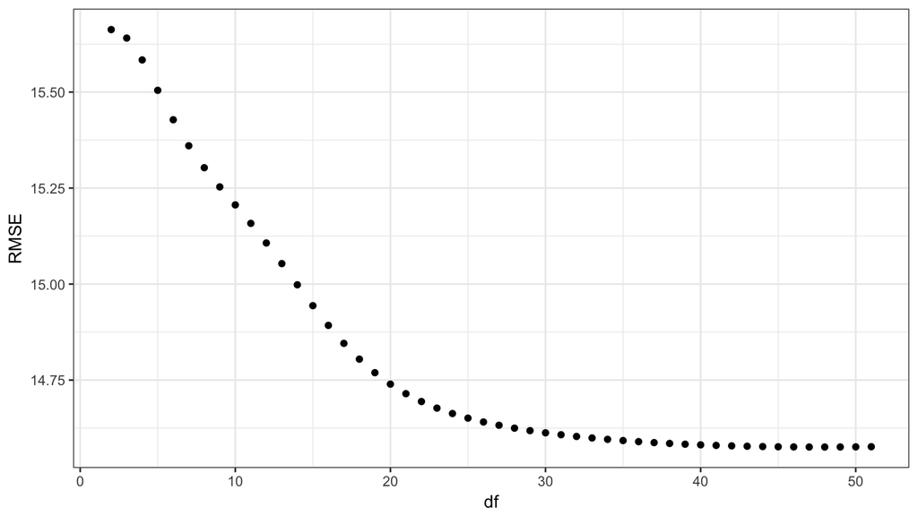

```r
# Only works for Fold 5
d1_samp_te5 = d1_samp_tr4

# removes pred column so that I can use rbind
d1_samp_te4 <- d1_samp_te4[-4]

# take the old test set and add it to the training set so that it's 2400 data points in the training set
d1_samp_tr5rb <- rbind(d1_samp_te,d1_samp_te2)
d1_samp_tr5rb <- rbind(d1_samp_te3,d1_samp_tr5rb)
d1_samp_tr5rb <- rbind(d1_samp_te4,d1_samp_tr5rb)

dfs <- rep(2:51)
RMSEs <- rep(0, times=50) # RMSE's

for (i in 1:length(dfs)) {
  splines_model <- smooth.spline(x=d1_samp_tr5rb$x, y=d1_samp_tr5rb$y, df = dfs[i])
  d1_samp_te5$preds <- predict(splines_model,d1_samp_te5$x)$y
  n <- length(d1_samp_te5$preds)
  MSE <- (1/n)*sum((d1_samp_te5$y-d1_samp_te5$preds)^2)
  RMSE <- sqrt(MSE)
  RMSEs[i] <- RMSE
}

# Visualization arguing for model
dataframe <- data.frame(dfs,RMSEs)
ggplot(dataframe, aes(x=dfs)) + geom_point(aes(y=RMSEs)) + theme_bw() + labs(x="df", y="RMSE")
```

```r
RMSE.opt[5] <- min(RMSEs)
df.opt[5] <- which.min(RMSEs) + 1
```

```r
score <- mean(RMSE.opt)
mean(df.opt)
```

```
## [1] 34.8
```

Let’s choose df = 35. We choose $\widehat{\sigma}$ = 15.0277017 because the RMSE is our best estimate of $\sigma$.

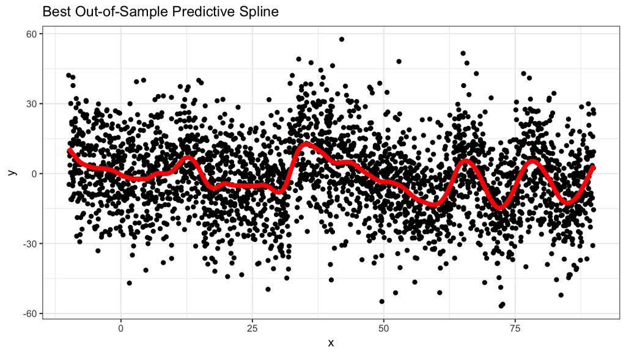

```r
splines_model <- smooth.spline(x=data1$x, y=data1$y, df=35)
splines_model_tidy <- splines_model %>%
  broom::augment()
plot <- ggplot(splines_model_tidy, aes(x=x)) +
  geom_point(aes(y=y)) +
  geom_line(aes(y=.fitted), col="red",size=2) + labs(title="Best Out-of-Sample Predictive Spline")
plot + theme_bw()
```

## Data 2

```r
set.seed(18)
RMSE.optd2 <- rep(0, times=5) # initialize vector of lowest RMSE's from 5 folds
df.optd2 <- rep(0, times=5) # initialize vector of df's corresponding to lowest RMSE's from 5 folds
```

### Fold 1

I split `data2` into k = 5 folds. In the first fold, I randomly create a disjoint training set and test (validation) set. The test set is a random sample of 600 data points (1/5 of the data points) from data2 and the rest of data2 becomes the training set. For the training set in this first fold, I fit a spline model. Then I use predict() to take the model and create $\hat{y}$ values for the test set. Next, I compute a score (root mean squared error) by comparing the $\hat{y}$ values for the test set with the actual y values.

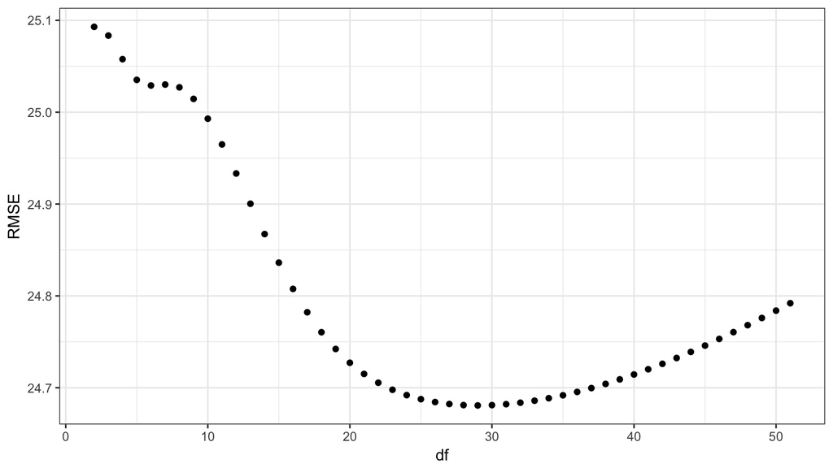

```r
# Create disjoint training and test data sets of size 2400 and 600, respectively
d2_samp_tr <- data2 %>% # data2_sample_train
  sample_n(2400)
d2_samp_te <- data2 %>% # data2_sample_test
  anti_join(d2_samp_tr, by="ID")

dfs <- rep(2:51)
RMSEs <- rep(0, times=50) # RMSE's

for (i in 1:length(dfs)) {
  splines_model <- smooth.spline(x=d2_samp_tr$x, y=d2_samp_tr$y, df = dfs[i])
  d2_samp_te$preds <- predict(splines_model,d2_samp_te$x)$y
  n <- length(d2_samp_te$preds)
  MSE <- (1/n)*sum((d2_samp_te$y-d2_samp_te$preds)^2)
  RMSE <- sqrt(MSE)
  RMSEs[i] <- RMSE
}

# Visualization arguing for model
dataframe <- data.frame(dfs,RMSEs)
ggplot(dataframe, aes(x=dfs)) + geom_point(aes(y=RMSEs)) + theme_bw() + labs(x="df", y="RMSE")
```

```r
RMSE.opt[1] <- min(RMSEs)
df.opt[1] <- which.min(RMSEs) + 1
```

### Fold 2

For fold 2, I start by choosing as a test set 1/5 of the data set that has not yet been part of the test set in fold 1. Practically speaking, this means choosing 1800 points from the training set of fold 1 to remain as the training set for fold 2, and then adding the 600 points from the test set of fold 1 to also be part of the training set in fold 2. Then I fit a spline model to the new training set. Use predict() to take the model and create y-hat values for the test set. Compute score by comparing the y-hat values of the test set with the actual y values.

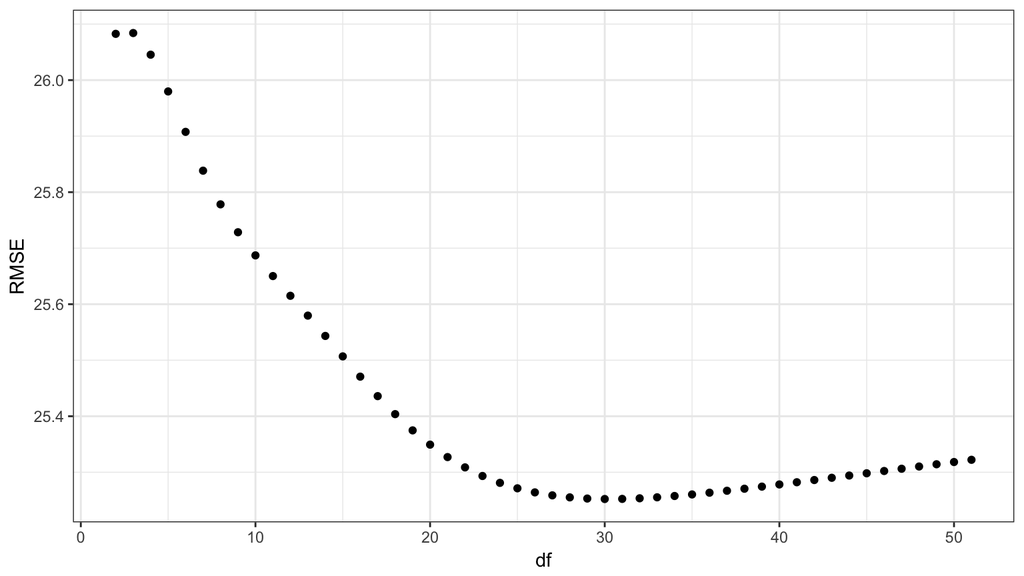

```r
# Repeat: sample 600 data points to be test set that are NOT in the previous test set
d2_samp_tr2 <- d2_samp_tr %>%
  sample_n(1800)
d2_samp_te2 <- d2_samp_tr %>%
  anti_join(d2_samp_tr2, by="ID")

# removes pred column so that I can use rbind
d2_samp_te <- d2_samp_te[-4]

# take the old test set and add it to the training set so that it's 2400 data points in the training set
d2_samp_tr2rb <- rbind(d2_samp_te,d2_samp_tr2)

dfs <- rep(2:51)
RMSEs <- rep(0, times=50) # RMSE's

for (i in 1:length(dfs)) {
  splines_model <- smooth.spline(x=d2_samp_tr2rb$x, y=d2_samp_tr2rb$y, df = dfs[i])
  d2_samp_te2$preds <- predict(splines_model,d2_samp_te2$x)$y
  n <- length(d2_samp_te2$preds)
  MSE <- (1/n)*sum((d2_samp_te2$y-d2_samp_te2$preds)^2)
  RMSE <- sqrt(MSE)
  RMSEs[i] <- RMSE
}

# Visualization arguing for model
dataframe <- data.frame(dfs,RMSEs)
ggplot(dataframe, aes(x=dfs)) + geom_point(aes(y=RMSEs)) + theme_bw() + labs(x="df", y="RMSE")
```

```r
RMSE.opt[2] <- min(RMSEs)
df.opt[2] <- which.min(RMSEs) + 1
```

### Fold 3

Fold 3 is similar to fold 2. I start by choosing as a test set 1/5 of the data set that has not yet been part of the test set in folds 1 and 2. Practically speaking, this means choosing 1200 points from the training set of fold 2 to remain as the training set for fold 3, and then adding the 1200 points from the test sets of folds 1 and 2 to also be part of the training set in fold 3.

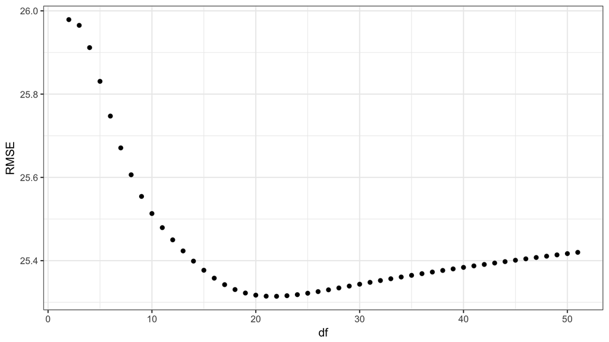

```r
# Repeat: sample 600 data points to be test set that are NOT in the previous test set
d2_samp_tr3 <- d2_samp_tr2 %>%
  sample_n(1200)
d2_samp_te3 <- d2_samp_tr2 %>%
  anti_join(d2_samp_tr3, by="ID")

# removes pred column so that I can use rbind
d2_samp_te2 <- d2_samp_te2[-4]

# take the old test set and add it to the training set so that it's 2400 data points in the training set
d2_samp_tr3rb <- rbind(d2_samp_te,d2_samp_tr3)
d2_samp_tr3rb <- rbind(d2_samp_te2,d2_samp_tr3rb)

dfs <- rep(2:51)
RMSEs <- rep(0, times=50) # RMSE's

for (i in 1:length(dfs)) {
  splines_model <- smooth.spline(x=d2_samp_tr3rb$x, y=d2_samp_tr3rb$y, df = dfs[i])
  d2_samp_te3$preds <- predict(splines_model,d2_samp_te3$x)$y
  n <- length(d2_samp_te3$preds)
  MSE <- (1/n)*sum((d2_samp_te3$y-d2_samp_te3$preds)^2)
  RMSE <- sqrt(MSE)
  RMSEs[i] <- RMSE
}

# Visualization arguing for model
dataframe <- data.frame(dfs,RMSEs)
ggplot(dataframe, aes(x=dfs)) + geom_point(aes(y=RMSEs)) + theme_bw() + labs(x="df", y="RMSE")
```

```r
RMSE.opt[3] <- min(RMSEs)
df.opt[3] <- which.min(RMSEs) + 1
```

### Fold 4

See Fold 3 and follow through with similar logic!

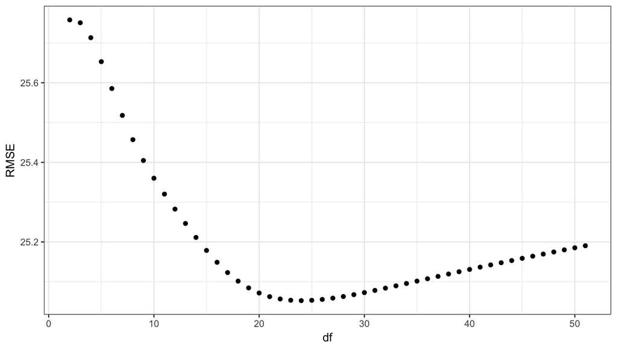

```r
# Repeat: sample 600 data points to be test set that are NOT in the previous test set
d2_samp_tr4 <- d2_samp_tr3 %>%
  sample_n(600)
d2_samp_te4 <- d2_samp_tr3 %>%
  anti_join(d2_samp_tr4, by="ID")

# removes pred column so that I can use rbind
d2_samp_te3 <- d2_samp_te3[-4]

# take the old test set and add it to the training set so that it's 2400 data points in the training set
d2_samp_tr4rb <- rbind(d2_samp_te,d2_samp_tr4)
d2_samp_tr4rb <- rbind(d2_samp_te2,d2_samp_tr4rb)
d2_samp_tr4rb <- rbind(d2_samp_te3,d2_samp_tr4rb)

dfs <- rep(2:51)
RMSEs <- rep(0, times=50) # RMSE's

for (i in 1:length(dfs)) {
  splines_model <- smooth.spline(x=d2_samp_tr4rb$x, y=d2_samp_tr4rb$y, df = dfs[i])
  d2_samp_te4$preds <- predict(splines_model,d2_samp_te4$x)$y
  n <- length(d2_samp_te4$preds)
  MSE <- (1/n)*sum((d2_samp_te4$y-d2_samp_te4$preds)^2)
  RMSE <- sqrt(MSE)
  RMSEs[i] <- RMSE
}

# Visualization arguing for model
dataframe <- data.frame(dfs,RMSEs)
ggplot(dataframe, aes(x=dfs)) + geom_point(aes(y=RMSEs)) + theme_bw() + labs(x="df", y="RMSE")
```

```r
RMSE.opt[4] <- min(RMSEs)
df.opt[4] <- which.min(RMSEs) + 1
```

### Fold 5

For Fold 5, the test set is composed of the training set from Fold 4 (all of the other points are parts of test sets in other folds). The training set is the combination of all of the test sets from the other folds.

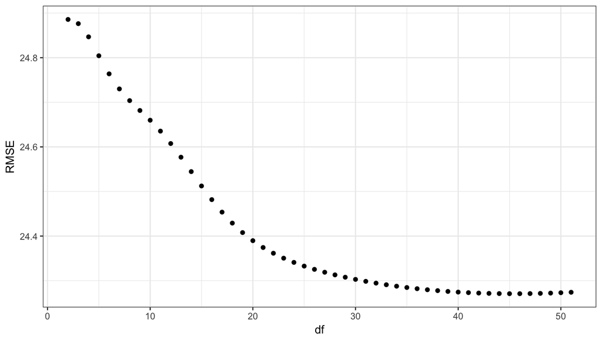

```r
# Only works for Fold 5
d2_samp_te5 = d2_samp_tr4

# removes pred column so that I can use rbind
d2_samp_te4 <- d2_samp_te4[-4]

# take the old test set and add it to the training set so that it's 2400 data points in the training set
d2_samp_tr5rb <- rbind(d2_samp_te,d2_samp_te2)
d2_samp_tr5rb <- rbind(d2_samp_te3,d2_samp_tr5rb)
d2_samp_tr5rb <- rbind(d2_samp_te4,d2_samp_tr5rb)

dfs <- rep(2:51)
RMSEs <- rep(0, times=50) # RMSE's

for (i in 1:length(dfs)) {
  splines_model <- smooth.spline(x=d2_samp_tr5rb$x, y=d2_samp_tr5rb$y, df = dfs[i])
  d2_samp_te5$preds <- predict(splines_model,d2_samp_te5$x)$y
  n <- length(d2_samp_te5$preds)
  MSE <- (1/n)*sum((d2_samp_te5$y-d2_samp_te5$preds)^2)
  RMSE <- sqrt(MSE)
  RMSEs[i] <- RMSE
}

# Visualization arguing for model
dataframe <- data.frame(dfs,RMSEs)
ggplot(dataframe, aes(x=dfs)) + geom_point(aes(y=RMSEs)) + theme_bw() + labs(x="df", y="RMSE")
```

```r
RMSE.opt[5] <- min(RMSEs)
df.opt[5] <- which.min(RMSEs) + 1
```

```r
score <- mean(RMSE.opt)
mean(df.opt)
```

```
## [1] 30
```

Let’s choose df = 30. We choose $\widehat{\sigma}$ = 24.9141761 because the RMSE is our best estimate of $\sigma$.

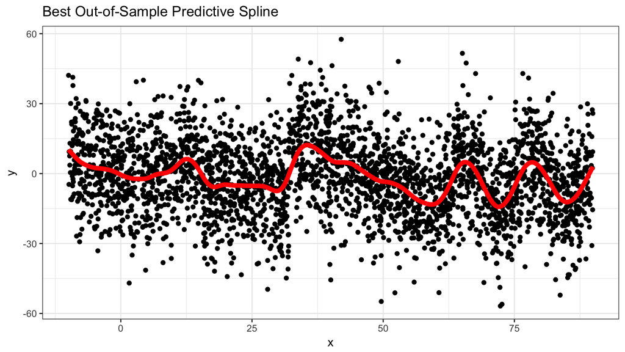

```r
splines_model <- smooth.spline(x=data1$x, y=data1$y, df=30)
splines_model_tidy <- splines_model %>%
  broom::augment()
plot <- ggplot(splines_model_tidy, aes(x=x)) +
  geom_point(aes(y=y)) +
  geom_line(aes(y=.fitted), col="red",size=2) + labs(title="Best Out-of-Sample Predictive Spline")
plot + theme_bw()
```